# Mathematical Modeling of AZ Covid Data

## Data Cleaning

```python
#Import the necessary packages to visualize our data
import pandas as pd
import numpy as np
import matplotlib.pyplot as plt
#Load the data from csv file into a pandas dataframe
covid_pd = pd.read_csv('Covid-19.csv', parse_dates = ['date'])

#Visualize the first few rows of our dataframe
covid_pd.head()
```

|  | state | date | critical_staffing_shortage_today_yes | critical_staffing_shortage_today_no | critical_staffing_shortage_today_not_reported | critical_staffing_shortage_anticipated_within_week_yes | critical_staffing_shortage_anticipated_within_week_no | critical_staffing_shortage_anticipated_within_week_not_reported | hospital_onset_covid | hospital_onset_covid_coverage | ... | previous_day_admission_pediatric_covid_confirmed_5_11 | previous_day_admission_pediatric_covid_confirmed_5_11_coverage | previous_day_admission_pediatric_covid_confirmed_unknown | previous_day_admission_pediatric_covid_confirmed_unknown_coverage | staffed_icu_pediatric_patients_confirmed_covid | staffed_icu_pediatric_patients_confirmed_covid_coverage | staffed_pediatric_icu_bed_occupancy | staffed_pediatric_icu_bed_occupancy_coverage | total_staffed_pediatric_icu_beds | total_staffed_pediatric_icu_beds_coverage |
| --- | --- | --- | --- | --- | --- | --- | --- | --- | --- | --- | --- | --- | --- | --- | --- | --- | --- | --- | --- | --- | --- |
| 0 | RI | 2021-02-13 | 4 | 10 | 1 | 4 | 10 | 1 | 5.0 | 14 | ... | NaN | 0 | NaN | 0 | NaN | 0 | 74.0 | 14 | 80.0 | 14 |
| 1 | AK | 2021-02-05 | 1 | 23 | 0 | 1 | 23 | 0 | 0.0 | 24 | ... | NaN | 0 | NaN | 0 | NaN | 0 | 57.0 | 24 | 74.0 | 24 |
| 2 | MA | 2021-02-02 | 8 | 70 | 1 | 7 | 71 | 1 | 58.0 | 78 | ... | NaN | 0 | NaN | 0 | NaN | 0 | NaN | 0 | NaN | 0 |
| 3 | KS | 2021-01-26 | 10 | 128 | 3 | 16 | 122 | 3 | 3.0 | 138 | ... | NaN | 0 | NaN | 0 | NaN | 0 | 38.0 | 138 | 219.0 | 138 |
| 4 | MD | 2021-01-20 | 2 | 56 | 1 | 2 | 56 | 1 | 30.0 | 58 | ... | NaN | 0 | NaN | 0 | NaN | 0 | 164.0 | 58 | 241.0 | 58 |

5 rows × 135 columns

```python
# Focus on hospitalizations using inpatient_beds_used_covid column
covid_pd = covid_pd[['state','date','inpatient_beds_used_covid']]
#Rename column
covid_pd.rename({'inpatient_beds_used_covid':'Hospitalizations'}, axis = 1, inplace = True)
```

```python
covid_pd = covid_pd[covid_pd['state'] == 'AZ'] # Extract data for Arizona
covid_pd = covid_pd.sort_values('date') #Order based on date
#Re-visualize table
covid_pd.head()
```

|  | state | date | Hospitalizations |
| --- | --- | --- | --- |
| 20720 | AZ | 2020-03-02 | 0.0 |
| 14351 | AZ | 2020-03-03 | 0.0 |
| 19060 | AZ | 2020-03-04 | 0.0 |
| 17686 | AZ | 2020-03-05 | 0.0 |
| 17615 | AZ | 2020-03-06 | 0.0 |

```python
#Let's reset the index for this new sorted dataframe
covid_pd.reset_index(drop=True, inplace=True)
covid_pd.head()
```

|  | state | date | Hospitalizations |
| --- | --- | --- | --- |
| 0 | AZ | 2020-03-02 | 0.0 |
| 1 | AZ | 2020-03-03 | 0.0 |
| 2 | AZ | 2020-03-04 | 0.0 |
| 3 | AZ | 2020-03-05 | 0.0 |
| 4 | AZ | 2020-03-06 | 0.0 |

```python
#Check to see if we have any null values at the moment
print(covid_pd.isnull().sum())
```

```
state               0
date                0
Hospitalizations    0
dtype: int64
```

Now our data has been cleaned! We filtered our data to show only hospitalizations for the state of Arizona and then sorted based on date. Also, our dataframe doesn't have any null values which is conveneint! Let's do a bit of visualization before we get started.

## Preliminary Visualization

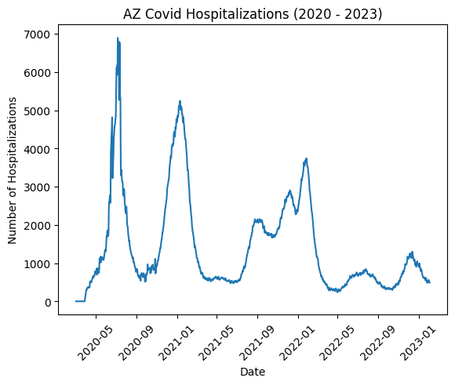

```python
#Plot covid data
plt.plot(covid_pd['date'], covid_pd['Hospitalizations'])
plt.xlabel('Date')
plt.ylabel('Number of Hospitalizations')
plt.title('AZ Covid Hospitalizations (2020 - 2023)')
plt.tick_params(axis='x', labelrotation = 45) # rotate X-lables to avoid overlap
```

Now let's see if we can use a system of differential equations to model the first major spike in hospitalizations. First, we'll edit our dataframe to only include dates up to 09/2020 to focus on the first spike in hospitalizations.

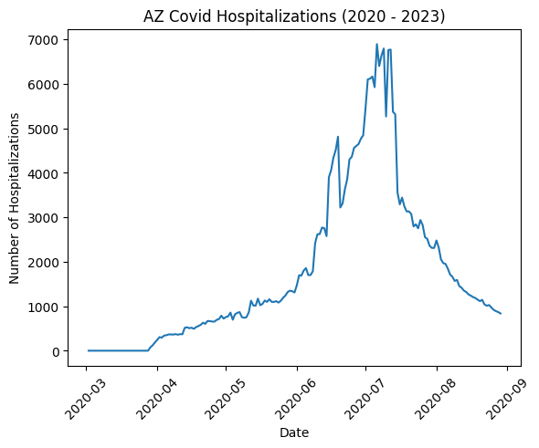

```python
covid_pd = covid_pd[covid_pd['date']<'2020-08-30']
plt.plot(covid_pd['date'], covid_pd['Hospitalizations'])
plt.xlabel('Date')
plt.ylabel('Number of Hospitalizations')
plt.title('AZ Covid Hospitalizations (2020 - 2023)')
plt.tick_params(axis='x', labelrotation = 45) # rotate X-lables to avoid overlap
```

## Mathematical Modeling

To approximate this data, we will use the SIHR model, which is a standard system of differential equations used to model the progression of disease. In the model, we have variables **S** (Suceptible), **I** (Infected), **H** (Hospitalized), and **R** (Recovered), which represent the number of people in each category. The system is as follows: \begin{align*} \frac{dS}{dt} & = -\frac{\beta S I}{N} \\ \frac{dI}{dt} & = \frac{\beta S I}{N} - \gamma I \\ \frac{dH}{dt} & = \gamma f I - c H \\ \frac{dR}{dt} & = \gamma (1-f) I + c H \end{align*}

In this model, infected people are progressed to the next stage H (hospitalization) or R (recovered) with the progression rate $\gamma$. Among these people, about $f=1\%$ of them developed severe symtoms and were hospitalized in early 2020. For those hospitalized, the daily recover rate was approximately $c=0.17$.

Our aim is to find the infection rate, $\beta$ and progression rate $\gamma$ manually to fit the data. In order to do this, we will create sliders to vary these two parameters

```python
#Import package to solve the system of differential equations
from scipy.integrate import odeint

#Create our Model

# Arizona Population from google search
N = 7.276 *(10**6)
# Initial number of infected and recovered individuals, I0 and R0.
I0, R0 = 1, 0
#Initial number of hospitalized individuals H0
H0 = 0
# Everyone else, S0, is susceptible to infection initially.
S0 = N - I0 - R0 - H0
# Contact rate, beta, and mean recovery rate, gamma, (in 1/days).
beta, gamma = .175, .05

#Add in parameters f and c, percent hospitalization and recovery rate (1/day)
f,c = 0.01, 0.17
# A grid of time points (in days)
t = np.linspace(0, 181, 181)

# The SIR model differential equations.
def deriv(y, t, N, beta, gamma,f,c):
    S, I, H, R = y
    dSdt = -beta * S * I / N
    dIdt = beta * S * I / N - gamma * I
    dHdt = gamma*f*I-c*H
    dRdt = gamma * (1-f)*I + c*H
    return dSdt, dIdt, dHdt, dRdt

# Initial conditions vector
y0 = S0, I0, H0, R0
# Integrate the SIHR equations over the time grid, t.
ret = odeint(deriv, y0, t, args=(N, beta, gamma,f,c))
S, I, H, R = ret.T
```

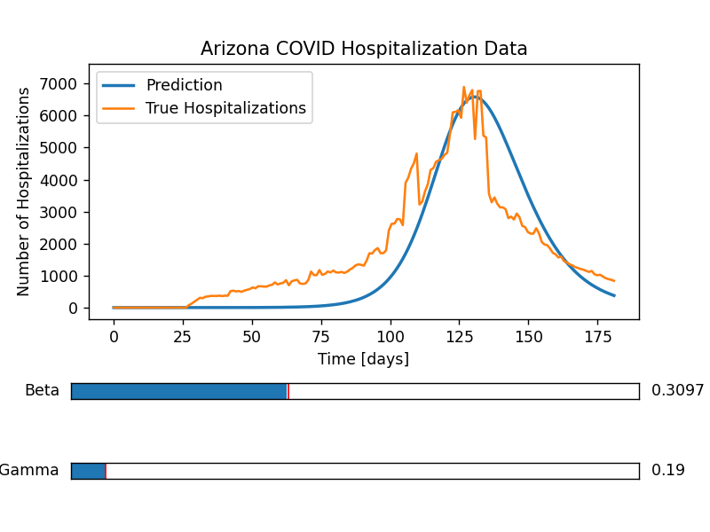

```python
#Allows for interactive plot and slider functionality
%matplotlib notebook
from matplotlib.widgets import Slider

#Create a figure object and plot Covid Data and our solution, H
fig, ax = plt.subplots()
line, = ax.plot(t, H, lw=2, label = 'Prediction') #This will be manipulated by our sliders
ax.plot(t,covid_pd['Hospitalizations'], label='True Hospitalizations')
ax.set_xlabel('Time [days]')
ax.set_ylabel('Number of Hospitalizations')
ax.set_title('Arizona COVID Hospitalization Data')
ax.legend()


# adjust the main plot to make room for the sliders
fig.subplots_adjust(bottom=0.4)

# Make a horizontal slider to control the gamma.
axgamma = fig.add_axes([0.1, 0.1, 0.8, 0.03])
gamma_slider = Slider(
    ax=axgamma,
    label='Gamma',
    valmin=0.01,
    valmax=3,
    valinit=0.19,
)

# Make another horizontal slider to control beta
axbeta = fig.add_axes([0.1, 0.25, 0.8, 0.03])
beta_slider = Slider(
    ax=axbeta,
    label="Beta",
    valmin=0.01,
    valmax=0.8,
    valinit= 0.3121,
)


# The function to be called anytime a slider's value changes
def update(val):
    ret = odeint(deriv, y0, t, args=(N, beta_slider.val, gamma_slider.val,f,c))
    S, I, H, R = ret.T
    line.set_ydata(H)
    fig.canvas.draw_idle()


# register the update function with each slider
beta_slider.on_changed(update)
gamma_slider.on_changed(update)

plt.show()
```

The parameters $\beta$ and $\gamma$ can be varied using our sliders to try to fit the data with our solution curve. I've found that values of $\beta=0.312$ and $\gamma = .19$ seem to approximate the data reasonably well, but one could continue to try different combinations to better fit our observed results. Interesting research has been done recently on the use of machine learning strategies to learn the parameters for our model. At some point, I aim to add an exploration of these concepts to this notebook.